# AvailableSeatsCsDept

2Lazy2BeOriginal

2025-05-01

# Introduction

The University Of Manitoba registration website (Aurora) contains track records dating back to Fall 2006. The goal of this document is to provide a visually pleasing way to accessing gradual change from Fall 2006 to Winter 2025. This is achieved by using the python library `Selenium` and webscrapping Aurora and copying certain data fields. A limitation with this approach is that there is no way of differentiating between days of the weeks are offered. This is because Aurora displays the weekday the class takes placed using a grid and coloured in squares and Selenium is unable to make the distinction.

Our dataset is stored in a data frame that contains the

- code (4 positive digits)
- section (Prefixed with ‘A’,‘B’,‘D’ or ‘T’ followed by a 2 digit code)
- capacity (natrual number)
- freeSpots (integer greater and including 0 but less than `capacity`)
- profName (String)
- Semester (Prefixed with ‘F’,‘W’ or ‘S’ then 2 digits that indicate year)

In particular we will see if there are certain patterns that determines a significant difference in Voluntary Withdrawl (VW) rates.

# Descriptive Statistics

## Summary of the professors with number of courses taught per year divided by year level

Each course has a leading digit which is used to break up into different levels (either 1000,2000,3000,4000) and this determines roughly the order a student should be taking courses. A student would take a course in the 1000 level then progress to 2000 level.

As professors/instructors teach more, they start teaching more advanced courses specializing in their research/interests. Below are selected professors who have the most notable growth.

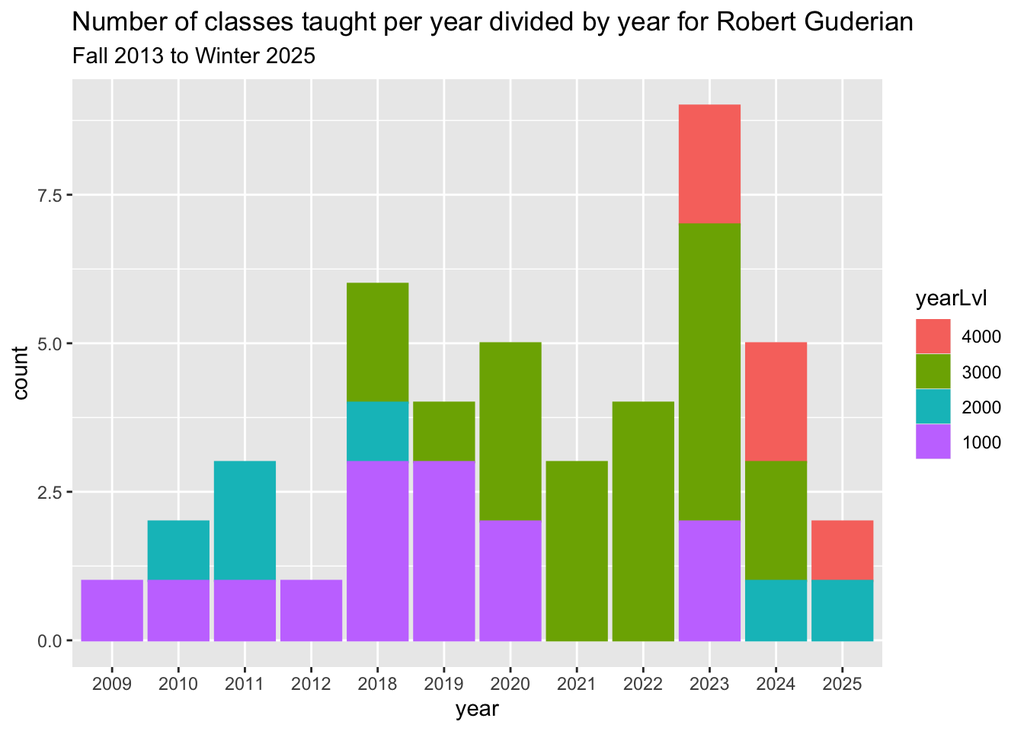

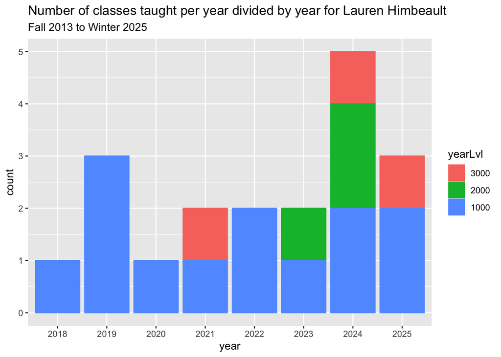

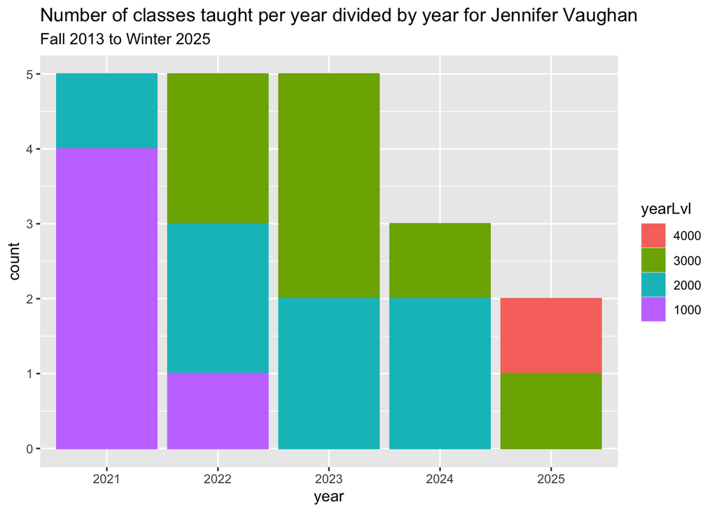

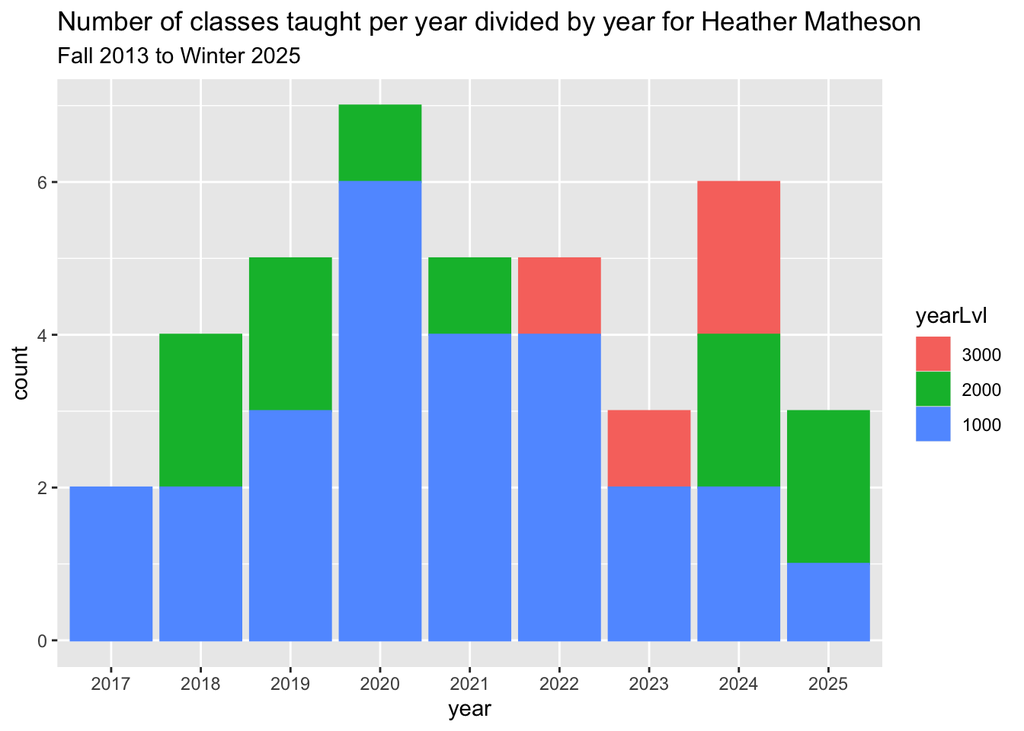

Three of the professors listed (Robert Guderian, Lauren Himbeault, and Jennifer Vaughan) are relatively new faculty members and it is interesting observing the pace the three have in progressing to teach higher level Computer Science classes.

Heather Matheson is the noticeable outlier. It is still possible to see her gradually shift from teaching 2000 level to 3000 but overall the growth seems stagnant. Perhaps she enjoys teaching first year courses more

Many other profs likely do not have as noticeable progression due to the data only dating back to Fall 2006. It seems that many were likely established and/or tenured prior to Fall2006 and so the data would appear stagnant for the more senior professors

## Which prof has been teaching the same course over and over

Some profs infamously just teach one course again and again. But which prof is the most guilty of not getting out of their comfort zone?

```r
getMostRepeatedCourse <- function(x) {
  # only prof taught
  df <- allUnderGradTbl[which(allUnderGradTbl$profName == x),]
  tbl <- table(df$code)
  return (sort(tbl, decreasing = TRUE)[1])
}

result <- sapply(compProfVec, getMostRepeatedCourse)
# profName, order gives the indices we care about indices
#index <- order(result, decreasing = TRUE)[1:10]
#compProfVec[index]
sort(result, decreasing = TRUE)[1:30]
```

```
##             Mehdi Niknam .1270    Mohammad Shorfuzzaman .1010
##                             24                             22
##            John Anderson .3190             Carson Leung .4710
##                             20                             19
##         Christina Penner .3040               Gord Boyer .1260
##                             19                             17
##            Alan Marshall .4520         Heather Matheson .1010
##                             16                             16
##            Helen Cameron .2140          Terrance Andres .1260
##                             16                             16
##              John Braico .1020    Parimala Thulasiraman .4510
##                             15                             14
##             Michael Zapp .2160                John Bate .1010
##                             12                             11
##       David Harvey Scuse .1020                Md Rahman .1260
##                             10                             10
##            John Van Rees .4140           Randall Cooper .2280
##                              9                              9
##         Rasit Eskicioglu .4430         Ruppa Thulasiram .3370
##                              9                              9
##              Adam Pazdor .1012 Amirhossein Hosseinmemar .1020
##                              8                              8
##              Andrea Bunt .3020         Franklin Bristow .3430
##                              8                              8
##       Michael Domaratzki .1010          Robert Guderian .3010
##                              8                              8
##        Stephane Durocher .4420            William Kocay .2190
##                              8                              8
##             Avery Miller .3030              James Young .1010
##                              7                              7
```

## Plot each open seat porportion based off class

If you want a certain prof highlighted, go to `cherryPickProf` and create a vector of names you want to be on the legend or not. THe default is all the profs that I used to test this but feel free to add. **Don’t forget to add a space to the end**

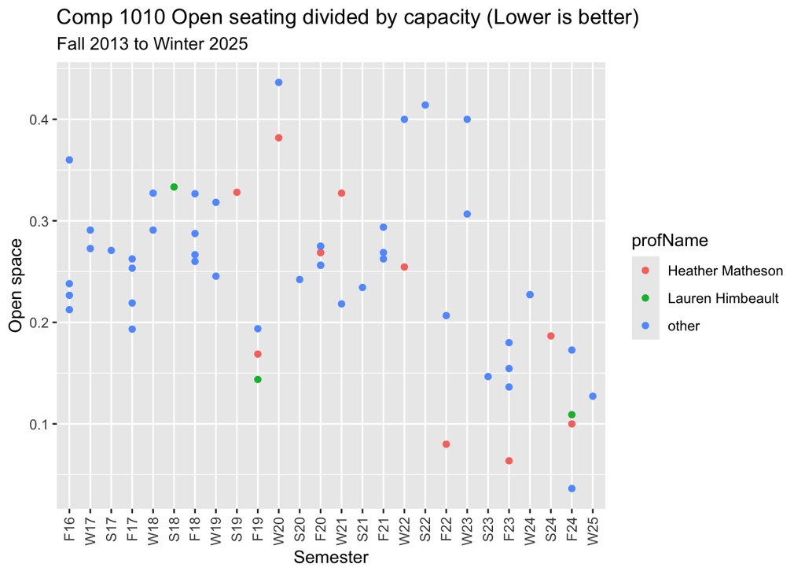

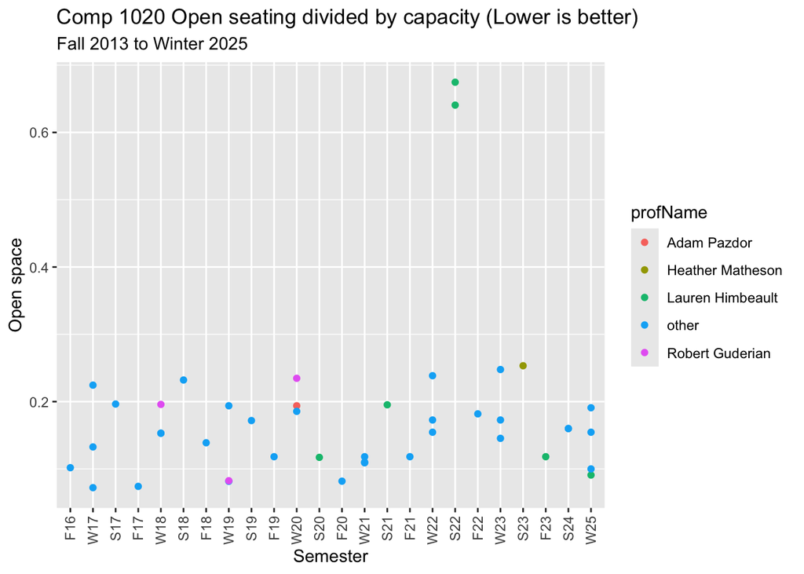

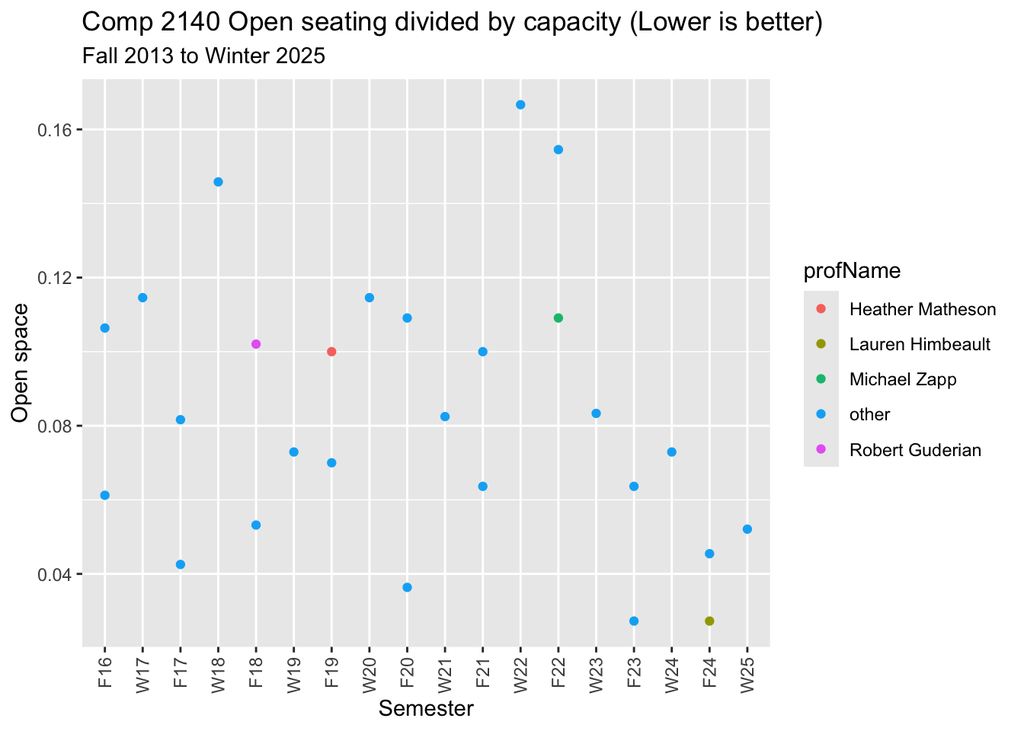

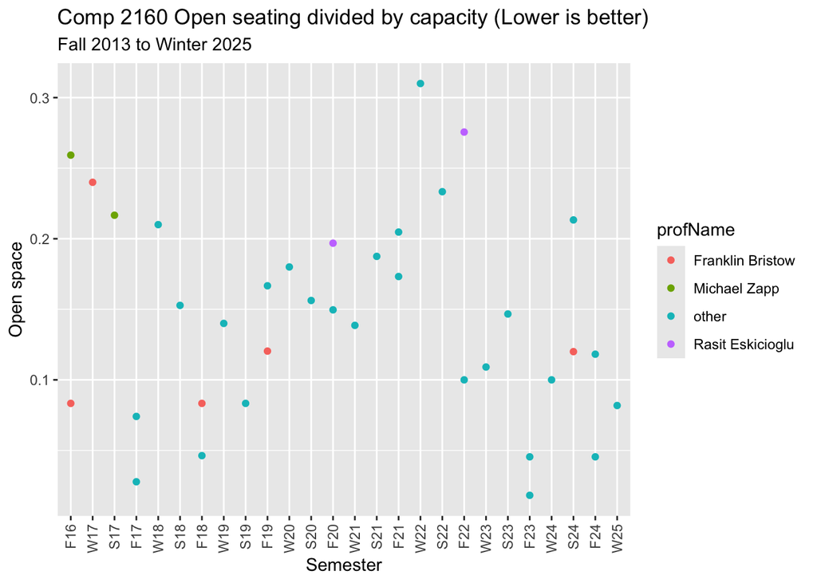

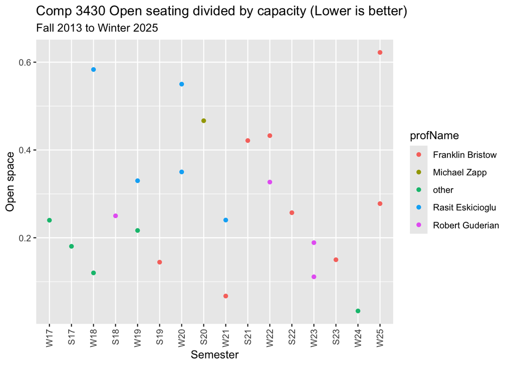

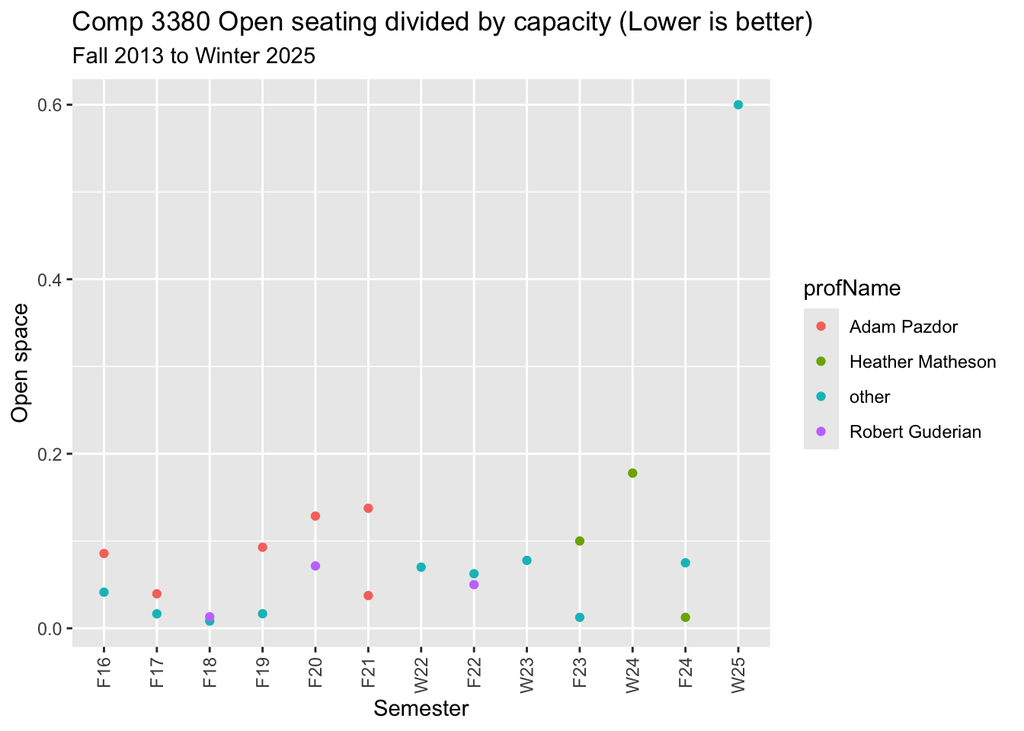

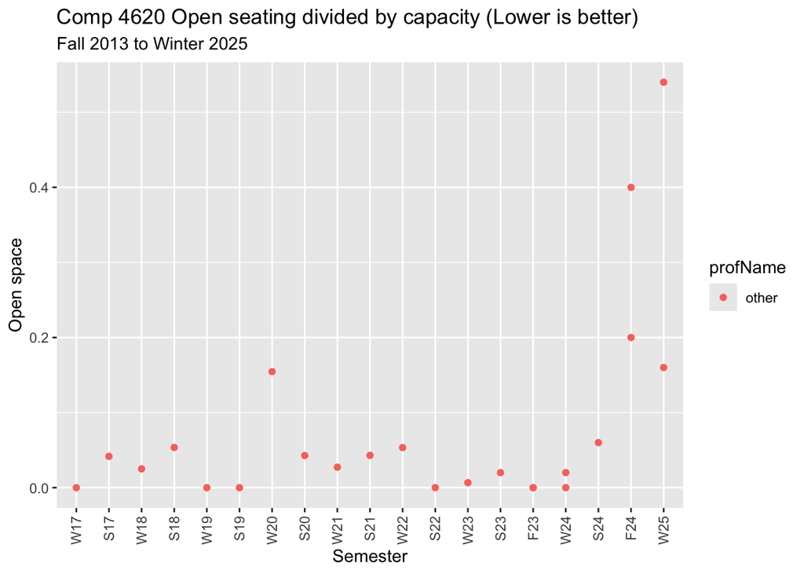

# Inferential Statistics

The follow sections will explore the relationship between withdraw rates among various factors. One key assumption in this is that the class sizes are full at the start of the semester. This will simplify calculations to a simple proportion in which we can just divide the open seats available (corresponds to number of students dropped in a course) with the capacity.

There is no definitive semester where this assumption is consistently met but for now, we will limit our dataset from Fall2018 to Winter2025

The primary test used will be the Chi-square test of independence. We have well established data and our groups are easily defined. (Note this assumes independence which is not the case since the same student would progress but for something to post on reddit this is fine)

## Does a course level have a higher drop rate in comparison to others

A natural assumption is that first year courses generally perform worse compared to later years.

### Test if there even is a difference

```
## [1] 8.312641e-126
```

Don’t take too seriously despite how obvious this sounds since this is missing an important assumption.

## Lauren

The plots would indicate that Lauren overall has a lower drop rate than other profs teaching the same course but is there a way to quantify this? The (naive) approach is to just pool all the students together disregarding the semester taught. And again use a chisq test of independence.

This is also not independent but it is more “believable” compared to the comparing 1000,2000 since the probability a student retakes a course **with the same professor** (considered resampling in this case) is exceptionally low.

Independence is broken due to students may for example have taken Lauren before and have a “slight” advantage compared to those who haven’t.

To Use this, the first parameter is the * code (4 digit code) * profName (Remember to add a space at the end because I am dumb :p )

To check overall trend it helps to plot each prof on their own and see if they tend to be lower on the graph (better) or higher

```
## [1] "1020 John Braico  p value  0.95776000704458"
```

```
## [1] "1010 Lauren Himbeault  p value  0.000350106211112789"
```

```
## [1] "1012 Lauren Himbeault  p value  8.82489705143124e-05"
```

```
## [1] "1020 Lauren Himbeault  p value  1.02413613800748e-24"
```

```
## [1] "2140 Lauren Himbeault  p value  0.0464727730636967"
```

```
## [1] "3350 Lauren Himbeault  p value  0.176665280645019"
```

```
## [1] "1010 Heather Matheson  p value  0.00416163756930645"
```

## Comp3430

Comp3430 has been infamously been taught by Rasit, but does the professor really affect how likely a student will drop the class or will students accept defeat and continue taking the class.

```
## [1] "3430 Robert Guderian  p value  8.04019042547188e-10"
## [2] "3430 Franklin Bristow  p value  8.04019042547188e-10"
## [3] "3430 Rasit Eskicioglu  p value  8.04019042547188e-10"
```

So yes there is a clear difference between Rasit and Franklin and Rob. Unfortunately this could either mean (Rasit is much worse than the other 2) or (Franklin/Rob is far better than the other 2). But the plot would clearly suggest Rasit is noticably worse. (Ignore the outlier in W25.) And also keep in mind the scale, it is from 20-60% drop rate

## which classes on average have higher drop rates

This pools all the sections together for a given code and then calculates the porportion of free spots over the capacity. This would ignore that some years perform worse but it isn’t that deep. (Lower is better)

```r
allCodes <- unique(shorternTbl$code)
myMeans <- sapply(allCodes, function(x) {y <- shorternTbl[which(shorternTbl$code == x),]
sum(y$freeSpots) / sum(y$capacity)
})
names(myMeans) <- allCodes
sort(myMeans)
```

```
##       4710       4050       3060       3350       2130       3040       4620
## 0.02077151 0.03664921 0.04000000 0.04603271 0.06065574 0.06086957 0.06945298
##       3380       3020       4380       4350       1270       4140       4020
## 0.08618267 0.10166667 0.10714286 0.11783439 0.11827957 0.12200000 0.12500000
##       1260       2280       2160       2140       3190       3030       2080
## 0.13212435 0.13536243 0.14359252 0.15092526 0.15156131 0.15611354 0.16198630
##       4820       1000       2600       3370       1600       4490       1012
## 0.17500000 0.18181818 0.20000000 0.20604703 0.20658683 0.23167155 0.23701621
##       2150       4580       4360       4300       4062       4190       3170
## 0.23840163 0.24390244 0.24761905 0.24888889 0.25000000 0.26111111 0.26588629
##       3010       4510       2002       3490       1002       3430       4560
## 0.27007733 0.27192982 0.28000000 0.28582677 0.28666667 0.28867470 0.29078014
##       1500       2190       4060       4420       1020       4550       2006
## 0.33023510 0.33888889 0.37769784 0.41000000 0.41524847 0.45294118 0.45833333
##       4520       4180       1010       3820       4430       1006       1011
## 0.48333333 0.50000000 0.53780333 0.59064327 0.60000000 0.70400000 0.73333333
##       1013       4990
## 0.83333333 0.95000000
```